# Praca Domowa 2

Jacek Wiśniewski

07/04/2021

### Wstęp

W tej pracy stworzę model predykcyjny do przewidywania ceny telefonu, który następnie przeanalizuję korzystając z wykresów Lime. Skupię się również na analizie działania wykresów Lime.

### Telefony którymi się będę zajmował

| name | brand | back_camera_mpix | front_camera_mpix | battery_mAh | ram_gb | flash_gb | diag | height_px | width_px | price |
| --- | --- | --- | --- | --- | --- | --- | --- | --- | --- | --- |
| Xiaomi Mi 10T 6+128GB | Xiaomi | 64 | 20 | 5000 | 6 | 128 | 6.67 | 2400 | 1080 | 1999 |
| Samsung Galaxy A71 | Samsung | 64 | 32 | 4500 | 6 | 128 | 6.70 | 2400 | 1080 | 1999 |
| Apple iPhone 7 Plus 32GB | Apple | 12 | 7 | 2900 | 3 | 32 | 5.50 | 1920 | 1080 | 1999 |

### Przewidywana cena pierwszego telefonu

| 1593.344 |
| --- |

### Wykres Lime dla pierwszego telefonu

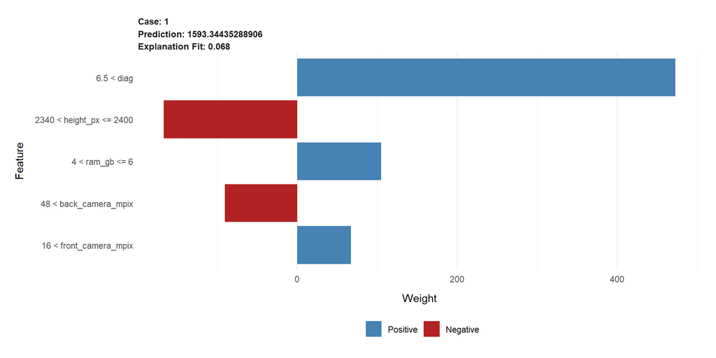

Na pierwszym wykresie widzimy 5 zmiennych, które miały największy wpływ na predykcję ceny pierwszego telefonu. Zgodnie z intuicją zachowują się zmienne opisujące przekątną telefonu oraz rozdzielczość przedniej kamery, ponieważ duże wartości tych zmiennych pozytywnie wpływają na cenę.

### Wykres Lime dla drugiego telefonu

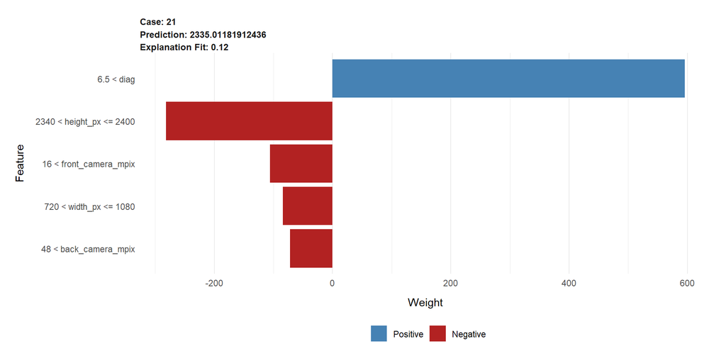

Z drugiego wykresu jesteśmy w stanie wyciągnąć podobne wnioski o wpływie diagonali na cenę telefonu, co z pierwszego wykresu. Zupełnie inaczej wygląda problem wpływu zmiennej front_camera_mpix. Na drugim wykresie ta zmienna ma negatywny wpływ na wynik, a na pierwszym pozytywny, mimo że warunek jest taki sam.

### Wykres Lime dla trzeciego telefonu

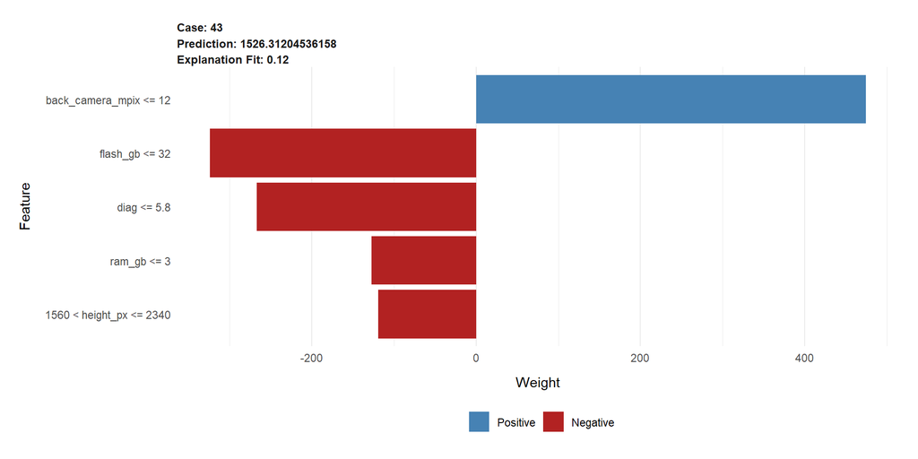

### Porównanie Break Down oraz Lime dla pierwszego telefonu

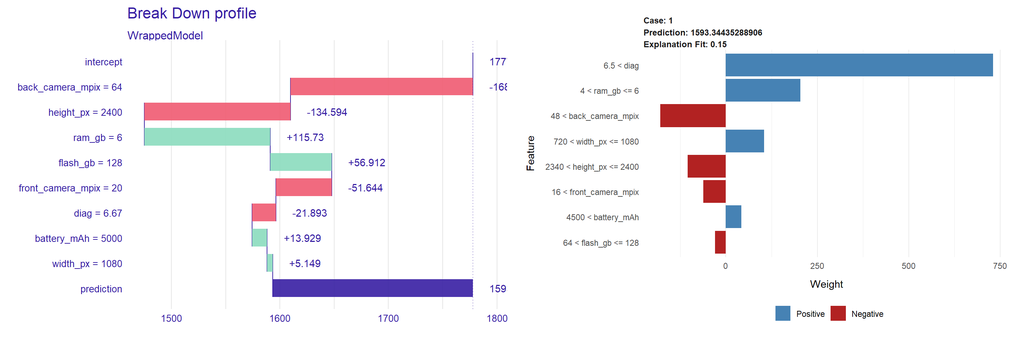

Większość zmiennych, które mają pozytywny wpływ na wykresie Break Down, ma również pozytywny wpływ na wykresie Lime. Wyjątkiem są zmienne diag oraz flash_gb.

### Wnioski

Otrzymane wyjaśnienia nie są stabilne. Zmienne o tych samych wartościach potrafią dawać przeciwne wpływy dla dwóch różnych oberwacji. Zmienna back_camera_mpix zachowuje się wbrew intuicji.